# SMART-Seq2 mRNA-Seq of blastocysts injected and nonInjected w active/dead-Btgh - embryo filtering and clustering

Sara Formichetti

EMBL Rome  
sara.formichetti@embl.it

July 12th, 2022

# 1 Design of the experiment

| sample | SRR | condition | group_or_time_point | batch | biol_rep | tech_rep | run | library_layout | read_length | perc_rDNA |
| --- | --- | --- | --- | --- | --- | --- | --- | --- | --- | --- |
| bC1 | none | non_injected | 1 | 3 | 1 | 1 | 1 | PAIRED - | 40 | 3.29 |
| bC10 | none | non_injected | 1 | 2 | 9 | 1 | 1 | PAIRED - | 40 | 6.50 |
| bC11 | none | non_injected | 1 | 2 | 10 | 1 | 1 | PAIRED - | 40 | 3.21 |
| bC12 | none | non_injected | 1 | 2 | 11 | 1 | 1 | PAIRED - | 40 | 6.06 |
| bC14 | none | non_injected | 1 | 1 | 12 | 1 | 1 | PAIRED - | 40 | 4.66 |
| bC15 | none | non_injected | 1 | 1 | 13 | 1 | 1 | PAIRED - | 40 | 5.30 |
| bC16 | none | non_injected | 1 | 1 | 14 | 1 | 1 | PAIRED - | 40 | 4.25 |
| bC17 | none | non_injected | 1 | 1 | 15 | 1 | 1 | PAIRED - | 40 | 3.32 |
| bC18 | none | non_injected | 1 | 1 | 16 | 1 | 1 | PAIRED - | 40 | 3.47 |
| bC19 | none | non_injected | 1 | 1 | 17 | 1 | 1 | PAIRED - | 40 | 4.29 |
| bC2 | none | non_injected | 1 | 3 | 2 | 1 | 1 | PAIRED - | 40 | 4.11 |
| bC26 | none | non_injected | 1 | 1 | 21 | 1 | 1 | PAIRED - | 40 | 2.76 |
| bC27 | none | non_injected | 1 | 1 | 22 | 1 | 1 | PAIRED - | 40 | 2.80 |
| bC3 | none | non_injected | 1 | 3 | 3 | 1 | 1 | PAIRED - | 40 | 4.04 |
| bC4 | none | non_injected | 1 | 3 | 4 | 1 | 1 | PAIRED - | 40 | 4.67 |
| bC5 | none | non_injected | 1 | 3 | 5 | 1 | 1 | PAIRED - | 40 | 3.43 |
| bC6 | none | non_injected | 1 | 3 | 6 | 1 | 1 | PAIRED - | 40 | 4.32 |
| bC7 | none | non_injected | 1 | 3 | 7 | 1 | 1 | PAIRED - | 40 | 5.31 |
| bC9 | none | non_injected | 1 | 3 | 8 | 1 | 1 | PAIRED - | 40 | 4.07 |
| bD1 | none | dead_Btgh | 1 | 3 | 1 | 1 | 1 | PAIRED - | 40 | 3.05 |
| bD10 | none | dead_Btgh | 1 | 2 | 10 | 1 | 1 | PAIRED - | 40 | 3.62 |
| bD11 | none | dead_Btgh | 1 | 2 | 11 | 1 | 1 | PAIRED - | 40 | 6.02 |
| bD15 | none | dead_Btgh | 1 | 2 | 12 | 1 | 1 | PAIRED - | 40 | 3.31 |
| bD16 | none | dead_Btgh | 1 | 2 | 13 | 1 | 1 | PAIRED - | 40 | 4.18 |
| bD17 | none | dead_Btgh | 1 | 2 | 14 | 1 | 1 | PAIRED - | 40 | 3.21 |
| bD18 | none | dead_Btgh | 1 | 2 | 15 | 1 | 1 | PAIRED - | 40 | 3.10 |
| bD19 | none | dead_Btgh | 1 | 1 | 16 | 1 | 1 | PAIRED - | 40 | 2.50 |
| bD2 | none | dead_Btgh | 1 | 3 | 2 | 1 | 1 | PAIRED - | 40 | 5.27 |
| bD20 | none | dead_Btgh | 1 | 1 | 17 | 1 | 1 | PAIRED - | 40 | 2.35 |
| bD21 | none | dead_Btgh | 1 | 1 | 18 | 1 | 1 | PAIRED - | 40 | 2.73 |
| bD22 | none | dead_Btgh | 1 | 1 | 19 | 1 | 1 | PAIRED - | 40 | 6.34 |
| bD23 | none | dead_Btgh | 1 | 1 | 20 | 1 | 1 | PAIRED - | 40 | 3.04 |
| bD3 | none | dead_Btgh | 1 | 3 | 3 | 1 | 1 | PAIRED - | 40 | 4.93 |
| bD4 | none | dead_Btgh | 1 | 3 | 4 | 1 | 1 | PAIRED - | 40 | 4.26 |
| bD5 | none | dead_Btgh | 1 | 3 | 5 | 1 | 1 | PAIRED - | 40 | 3.52 |
| bD6 | none | dead_Btgh | 1 | 2 | 6 | 1 | 1 | PAIRED - | 40 | 4.15 |
| bD7 | none | dead_Btgh | 1 | 2 | 7 | 1 | 1 | PAIRED - | 40 | 3.83 |
| bD8 | none | dead_Btgh | 1 | 2 | 8 | 1 | 1 | PAIRED - | 40 | 3.44 |
| bD9 | none | dead_Btgh | 1 | 2 | 9 | 1 | 1 | PAIRED - | 40 | 9.64 |
| bA1 | none | active_Btgh | 1 | 3 | 1 | 1 | 1 | PAIRED - | 40 | 3.71 |
| bA10 | none | active_Btgh | 1 | 2 | 10 | 1 | 1 | PAIRED - | 40 | 3.90 |
| bA11 | none | active_Btgh | 1 | 2 | 11 | 1 | 1 | PAIRED - | 40 | 3.24 |
| bA12 | none | active_Btgh | 1 | 2 | 12 | 1 | 1 | PAIRED - | 40 | 3.45 |
| bA13 | none | active_Btgh | 1 | 2 | 13 | 1 | 1 | PAIRED - | 40 | 3.41 |
| bA14 | none | active_Btgh | 1 | 2 | 14 | 1 | 1 | PAIRED - | 40 | 3.33 |
| bA15 | none | active_Btgh | 1 | 2 | 15 | 1 | 1 | PAIRED - | 40 | 4.56 |
| bA16 | none | active_Btgh | 1 | 1 | 16 | 1 | 1 | PAIRED - | 40 | 2.79 |
| bA17 | none | active_Btgh | 1 | 1 | 17 | 1 | 1 | PAIRED - | 40 | 3.11 |
| bA18 | none | active_Btgh | 1 | 1 | 18 | 1 | 1 | PAIRED - | 40 | 4.19 |
| bA19 | none | active_Btgh | 1 | 1 | 19 | 1 | 1 | PAIRED - | 40 | 3.27 |
| bA2 | none | active_Btgh | 1 | 3 | 2 | 1 | 1 | PAIRED - | 40 | 4.15 |
| bA3 | none | active_Btgh | 1 | 3 | 3 | 1 | 1 | PAIRED - | 40 | 4.22 |
| bA4 | none | active_Btgh | 1 | 3 | 4 | 1 | 1 | PAIRED - | 40 | 3.67 |
| bA5 | none | active_Btgh | 1 | 3 | 5 | 1 | 1 | PAIRED - | 40 | 3.25 |
| bA6 | none | active_Btgh | 1 | 2 | 6 | 1 | 1 | PAIRED - | 40 | 4.41 |
| bA7 | none | active_Btgh | 1 | 2 | 7 | 1 | 1 | PAIRED - | 40 | 3.70 |
| bA8 | none | active_Btgh | 1 | 2 | 8 | 1 | 1 | PAIRED - | 40 | 8.12 |
| bA9 | none | active_Btgh | 1 | 2 | 9 | 1 | 1 | PAIRED - | 40 | 7.95 |

# 2 Quality filtering of embryos

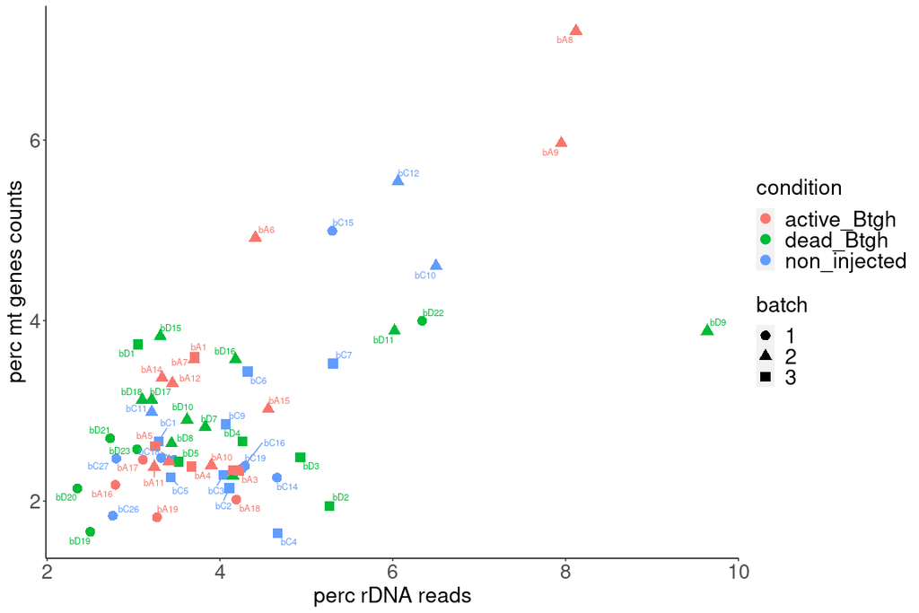

I remove samples bA9, bA8, bD9 because outliers in the scatterplot.

I also exclude samples which are potentially anaeuploidic based on result in ‘Diff_allelic_expression_from_featureCounts’ Rmd.

# 3 Counts of Btgh RNA molecules

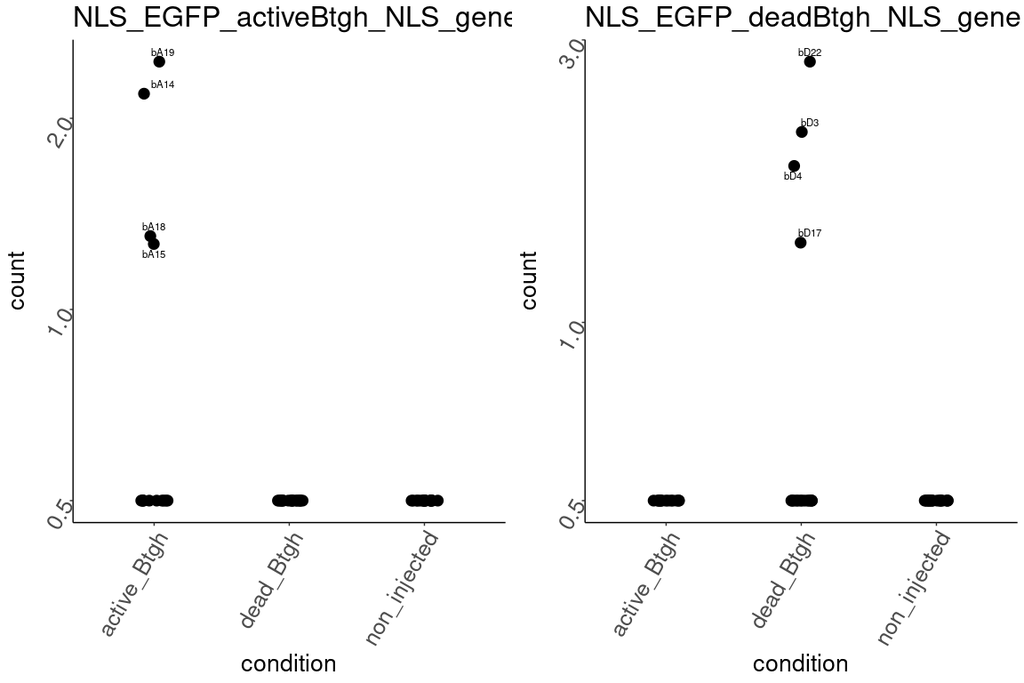

The Btgh mRNA is not detectable anymore at this embryo stage. From now on, I remove the transgenes from the data.

# 4 Establishing sex of embryos

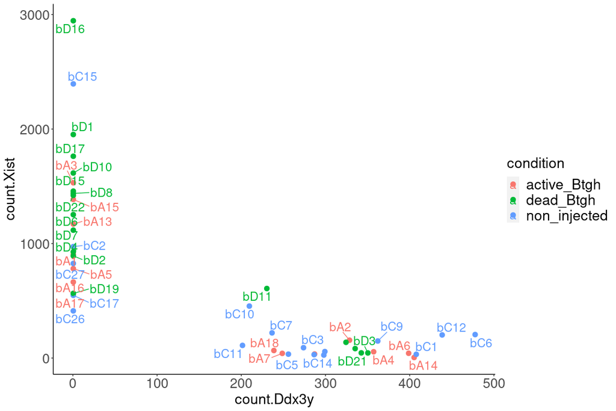

I define as males those embryos with counts for Ddx3y > 150.

# 5 Sample clustering

## 5.1 Heatmap for quality assessment

After applying the log2(n + 1) transformation, I plot heatmaps of normalized counts for top highly expressed genes to check for eventual big sample heterogeneity present in the dataset.

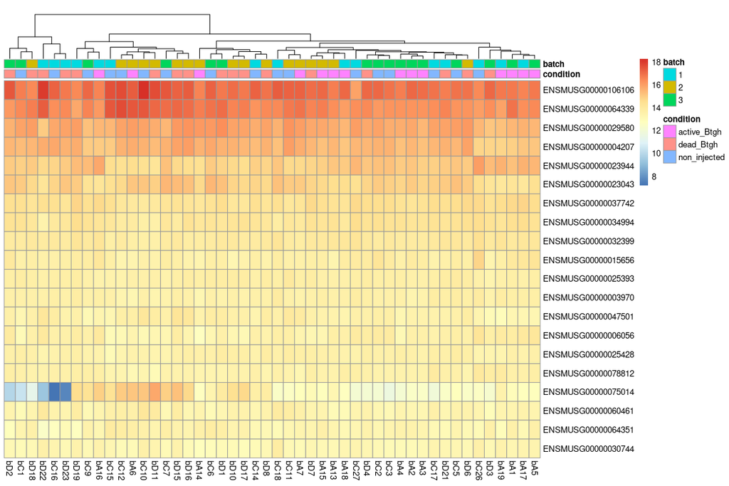

No major samples heterogeneity.

## 5.2 PCA

For this PCA:

1. I start with DESeq2-normalized data
2. I keep only genes with DESeq2-normalized mean across samples > 10
3. I apply log2 transformation
4. I perform PCA with package prcomp using the 1000 genes with the highest variance

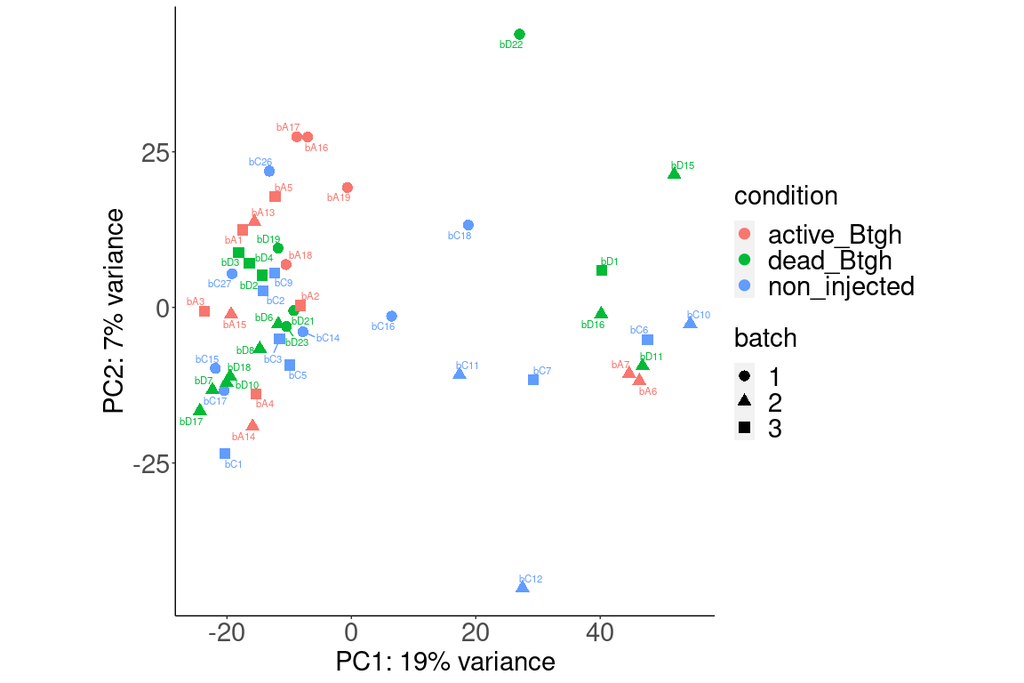

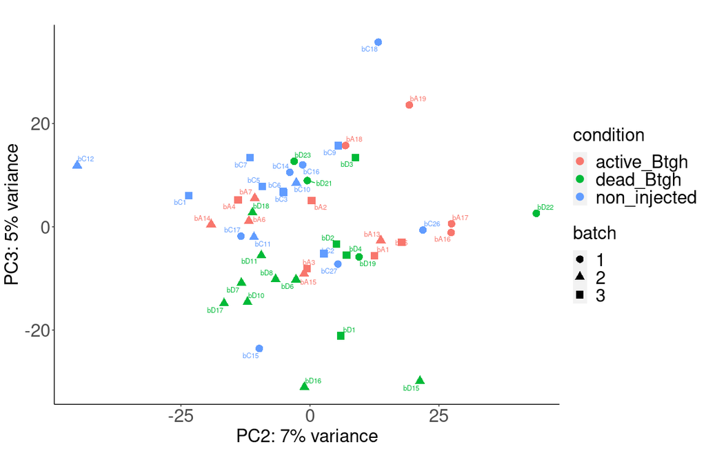

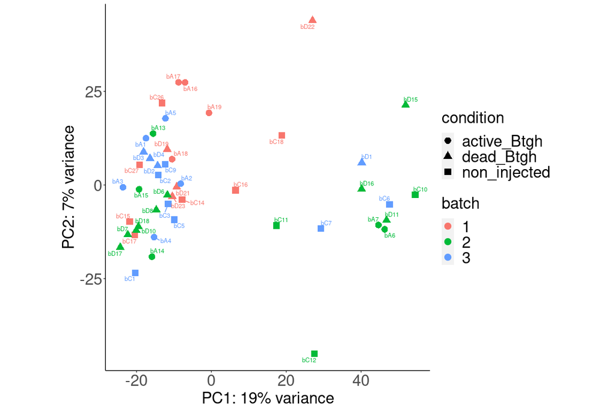

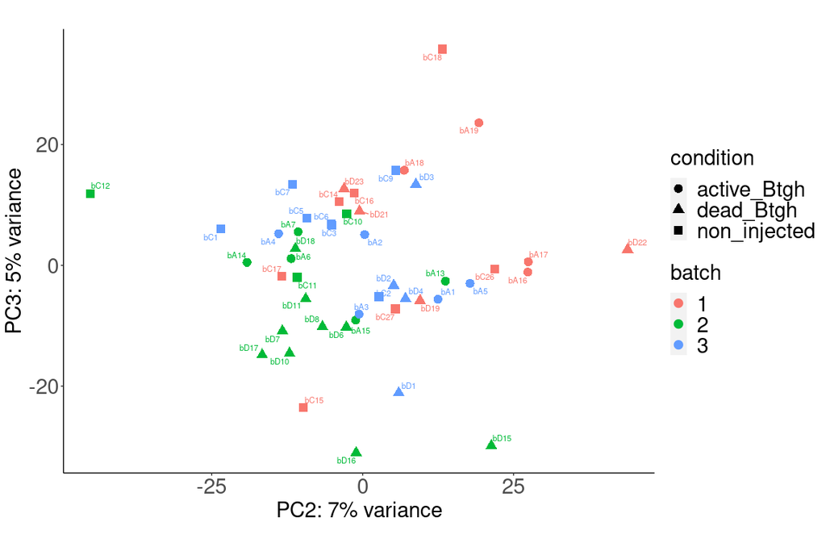

Two main conclusions:

- **Unwanted variation correlated with batch** is visible in PC2/3.
- No clear clustering due to experimental group.

I will try to remove the unwanted variation using package function **RUVs** of package **RUVSeq** and replot PCA to see whether something changes.

### 5.2.1 Examining RUVs effect via PCA and RLE plots

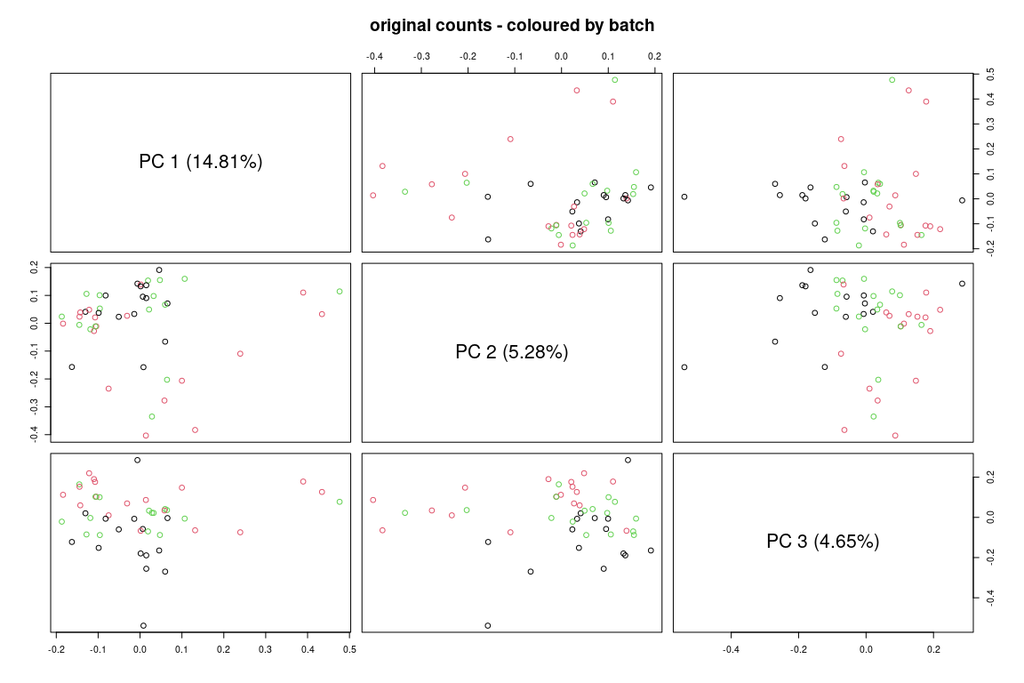

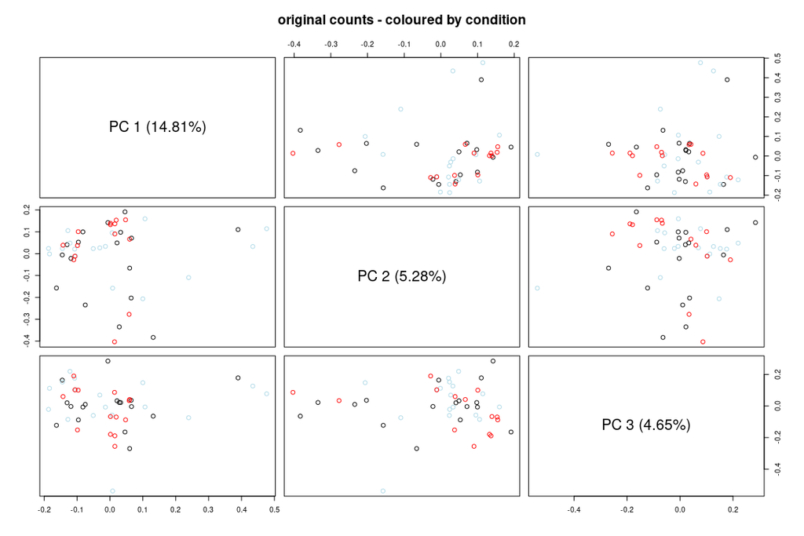

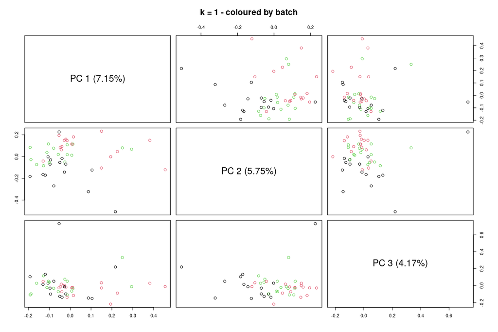

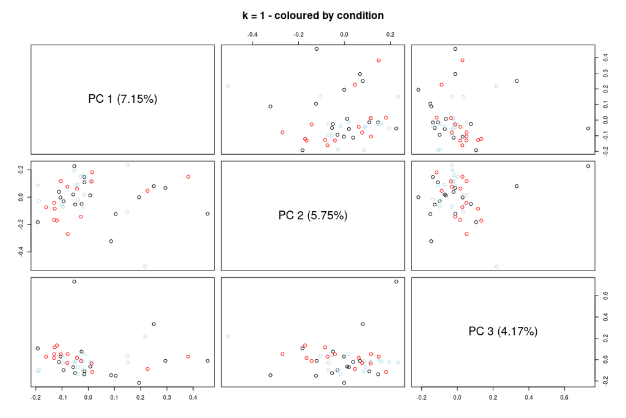

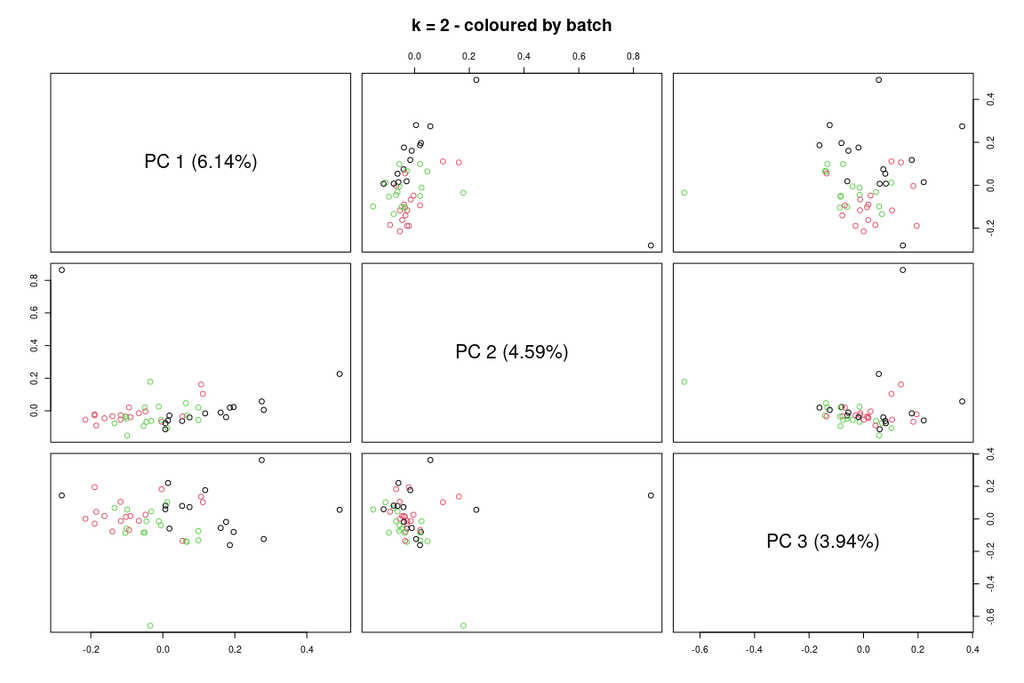

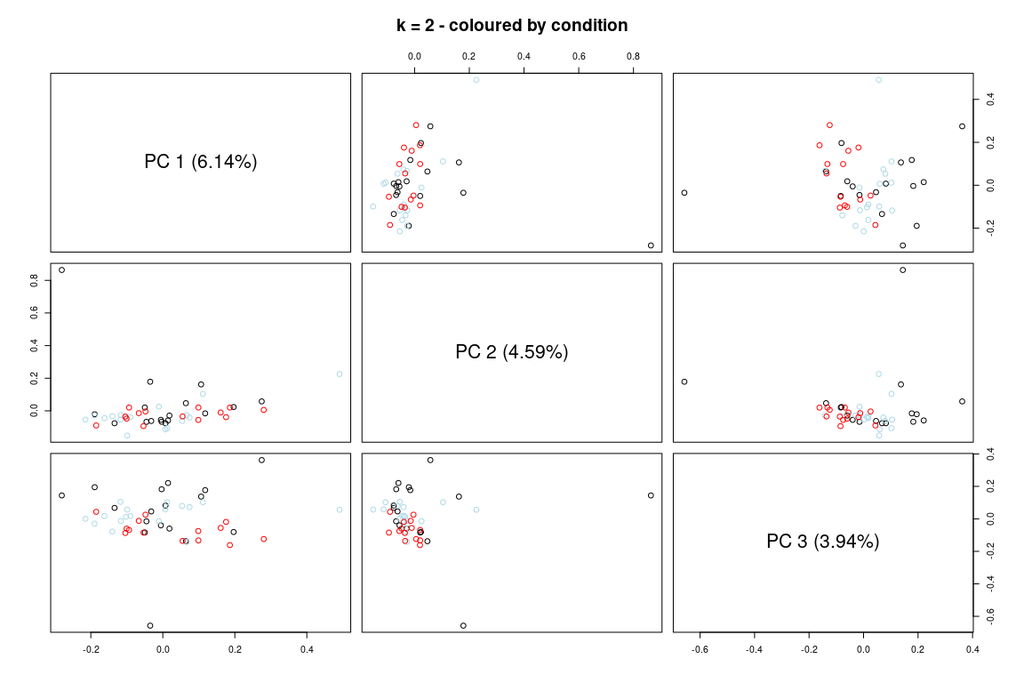

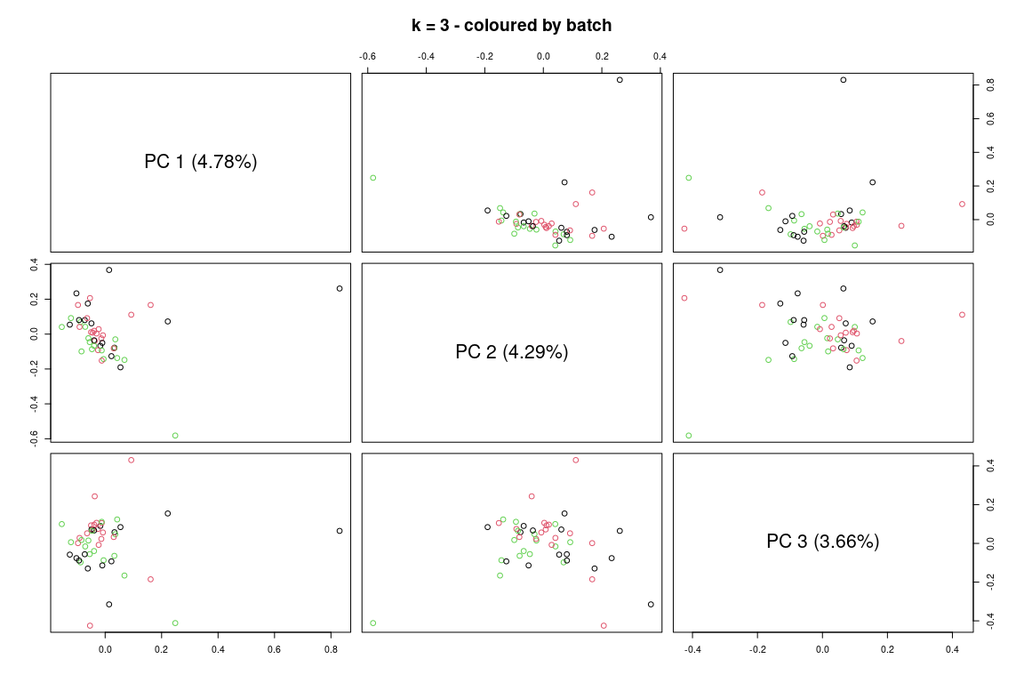

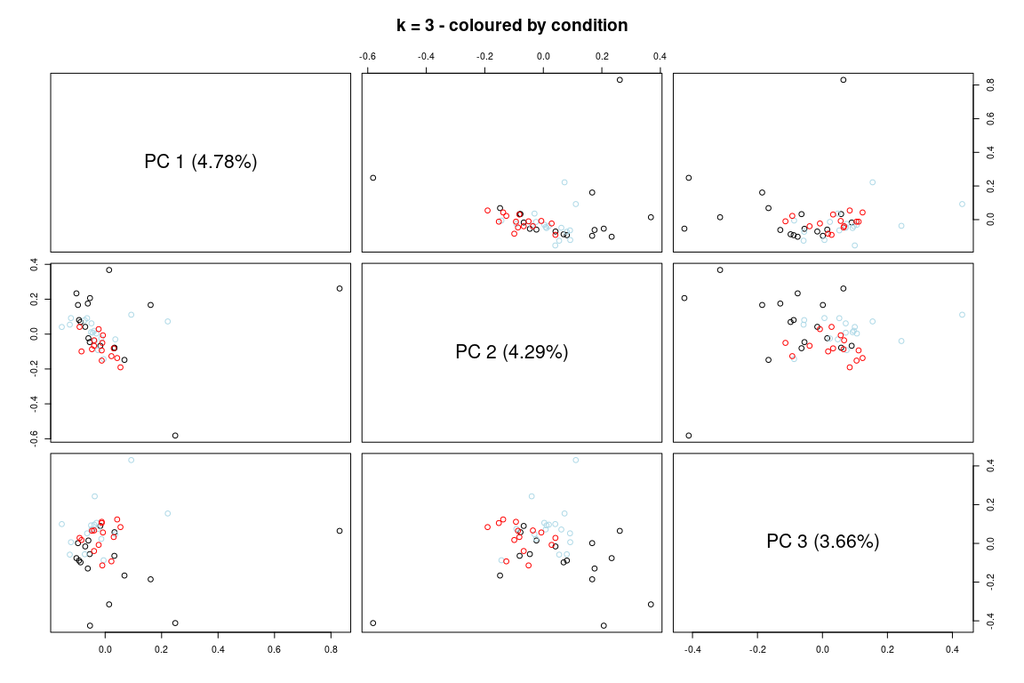

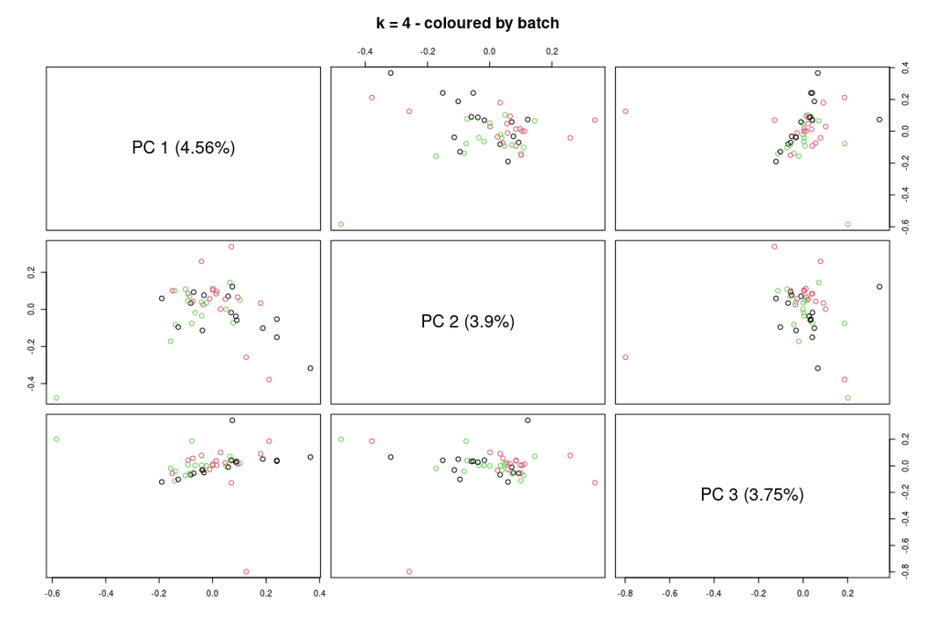

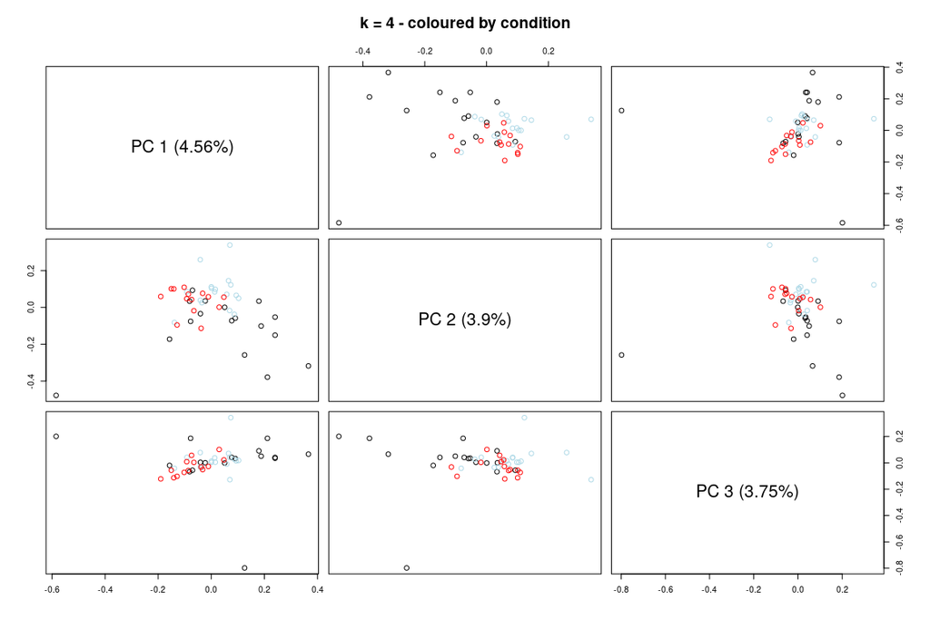

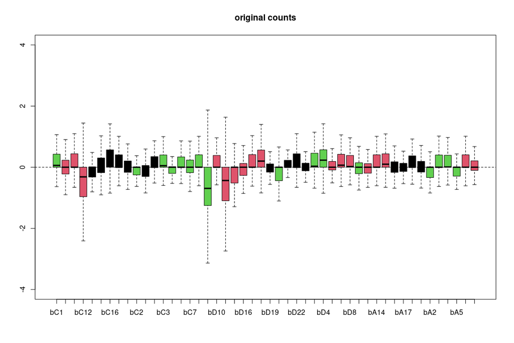

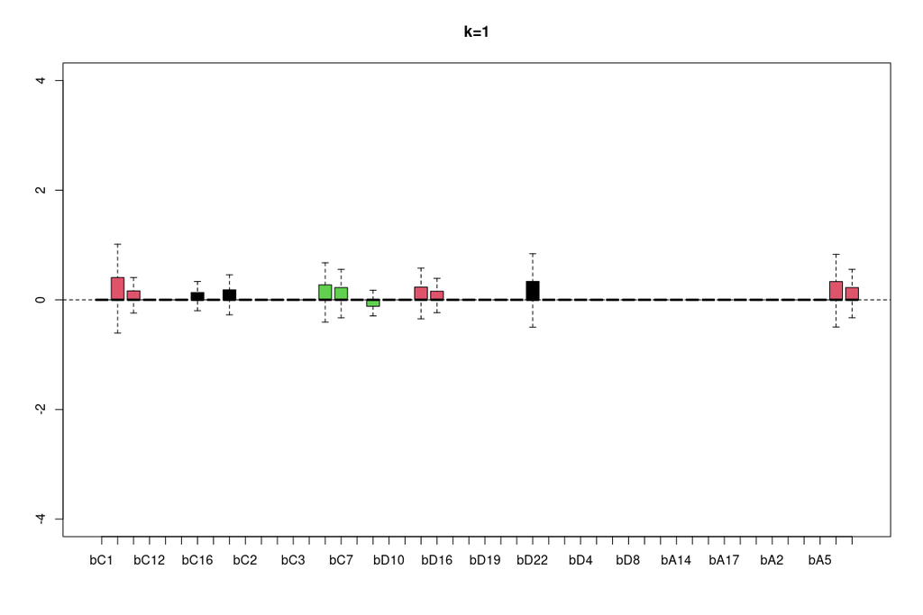

[2 more figures not shown]

RUVSeq starts to reduce the batch effect from k = 3 –> **I will use the first 3 factors of unwanted variation in DE analysis (DE_analysis.Rmd)**

# 6 Number of embryos after all filtering steps

The following numbers of embryos per conditions are left after all filtering steps. These will be input to the DE analysis in next Rmd.

```
##
##                 F  M
##   active_Btgh   7  7
##   dead_Btgh    12  5
##   non_injected  5 12
```